# Canada Covid 19 Visualization and Modeling

### **Cheng Ximen, CFA, FRM**

If you do not wish to see the raw code please click the button below

```python
%%HTML
<button onclick="$('.input, .prompt, .output_stderr, .output_error, .output_result').toggle();">Hide Code</button>
```

Like most people, following the news and data of the latest update on covid 19 situation in Canada and around the world has become part of my daily rountine for a while, hoping everyday we can get through the pandemic as soon as possible. Even though I'm far from qualified to give opinions about the situation, I thought it might be worth while to analyze the data from statistical point of view and use it as a reference to assess informations such as if things are getting better, how much longer it might last etc.

## Logistic Curve & Growth Factor

When I look at the curve that represents cumulative number of people confirmed to be infected by covid 19 disease, the first intuition is that it seems to grow exponentially, which makes perfect sense because at start as the number of infected people grows, more people are likely to be exposed to the disease, so every day newly infected rate will also be growing. However with the progression of the situation, we’ll also have less people who is very susceptible to the disease, either because they have got it before so have better immune system, or simply because they have more seclusive lifestyle or more cautious about the situation. Gradually the growth rate will start to decrease and the confimation curve will flatten out at certain level. Then logistic curve becomes a better way of simulating the growth. As the main difference between the two function is that in logistic fuctions the growth rate is not only affected by the base, it is also affected by how close the base is to the maximum cap. Please look at this [video](https://www.youtube.com/watch?v=Kas0tIxDvrg) and [article](https://www.khanacademy.org/science/biology/ecology/population-growth-and-regulation/a/exponential-logistic-growth) which really help clarify the question.

Now we have some assumption of how the confirmation curve should develop, in order to understand where we are in terms of the development of the curve, the most convenient way is to look at the growth factor, which is basicly the change rate of the new case today to previous day. If we use first derivative to calculate the growth rate of the confirmed number, growth rate can be represented using second derivative. I believe using positive and genative sign to see inflection point is more intuitive.

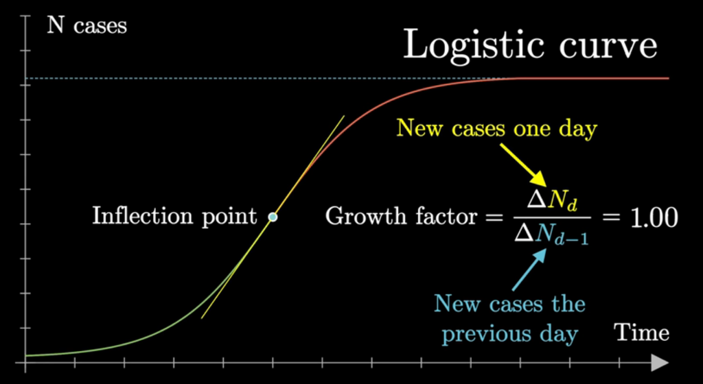

In the charts below besides the Canada national level, I'll also add in some major provinces where the covid 19 situation is more severe than others. The data is from the link here

```python
# import necessary libraries
import warnings
warnings.filterwarnings('ignore')
import pandas as pd
import numpy as np
import seaborn as sns
import matplotlib.pyplot as plt
import matplotlib.ticker as mtick
%matplotlib inline
import plotly.graph_objects as go
import matplotlib.ticker as ticker
import plotly.express as px
from fbprophet import Prophet
from fbprophet.plot import add_changepoints_to_plot
import gc
from datetime import datetime
from scipy.integrate import solve_ivp
from scipy.optimize import minimize
from datetime import timedelta
from sklearn.metrics import mean_squared_log_error, mean_squared_error
```

```python
data_confirmed = pd.read_csv('./covid19_official.csv')
# exclude date Apr 26 as it's not complete
data_confirmed = data_confirmed[data_confirmed.date!="26-04-2020"]
# create pie chart data
last_date = data_confirmed.date.iloc[-1]
df_pie = data_confirmed[data_confirmed.date==last_date][['prname','numconf']]
df_pie = df_pie[df_pie.prname!='Canada']
df_pie = df_pie[df_pie.numconf>100]
df_pie.columns = ['provinces','confirmed_cases']
```

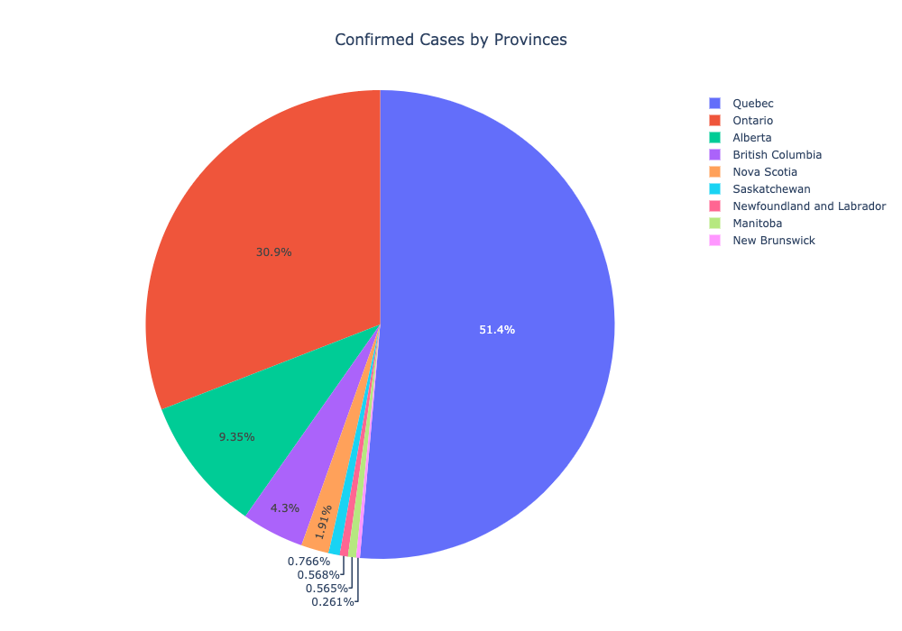

As we can see from the pie chart, Quebec, Ontario, Alberta, BC constitute the majority of the confirmed cases in Canada. So those are the provinces that we should pay more attentions to. And based on our analysis above, I'll plot out the absolute value, growth rate and growth factor of confirmed cases by provinces to get some basic understanding of the development of the disease. The growth rate and growth factor data are smoothed using expnontial weight of past 5 days window.

```python
def smoother(inputdata,w,imax):
    data = 1.0*inputdata
    data = data.replace(np.nan,1)
    data = data.replace(np.inf,1)
    smoothed = 1.0*data
    normalization = 1
    count=0
    for i in range(imax):
        if i==0:
            continue
        smoothed += (w**abs(i))*data.shift(i,axis=0)
        normalization += w**abs(i)
    smoothed /= normalization
    return smoothed

def plot_growth(df,geo):
    df = df[df.prname==geo][['date','numconf']].dropna()
    df.columns = ['date','total_confirmed']
    df.date = df.date.apply(lambda x: datetime.strptime(x,'%d-%m-%Y'))
    # add growth rate
    smooth_weight = 0.5
    smooth_windown = 5
    df['daily_growth(first_derivative)'] = np.clip(np.gradient(df['total_confirmed']),0,np.inf)
    df['daily_growth(first_derivative)'] = smoother(df['daily_growth(first_derivative)'],smooth_weight,smooth_windown)
    # add growth factor
    df['growth_factor(second_derivative)'] = np.gradient(df['daily_growth(first_derivative)'])
    df['growth_factor(second_derivative)'] = smoother(df['growth_factor(second_derivative)'],smooth_weight,smooth_windown)
    # first chart
    fig,axs = plt.subplots(1,2,figsize=(21,6))
    axs[0].plot(df.date,df['total_confirmed'].values,color='tab:red',linewidth=3,label='total_confirmed')

    ax2 = axs[0].twinx()
    ax2.bar(df.date,df['daily_growth(first_derivative)'].values,alpha=0.7,label='daily_growth(first_derivative)')
    axs[0].xaxis.set_major_locator(ticker.MaxNLocator(len(df.date[::3])))
    plt.setp( axs[0].xaxis.get_majorticklabels(), rotation=90 )
    axs[0].legend()
    ax2.legend(loc='center left')
    axs[0].set_title(f'{geo} Covid 19 Growth')
    # second chart

    axs[1].plot(df.date,df['growth_factor(second_derivative)'].values,linewidth=3,label='growth_factor(second_derivative)')
    axs[1].xaxis.set_major_locator(ticker.MaxNLocator(len(df.date[::3])))
    plt.setp( axs[1].xaxis.get_majorticklabels(), rotation=90 )
    axs[1].axhline(linestyle='-.',alpha=0.7)
    axs[1].legend(loc='upper left')
    axs[1].set_title(f'{geo} Covid 19 Growth')
    axs[1].set_xlabel('date')
    plt.show()
```

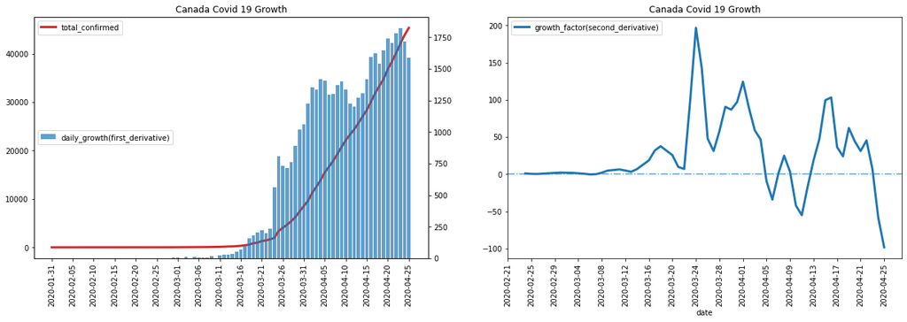

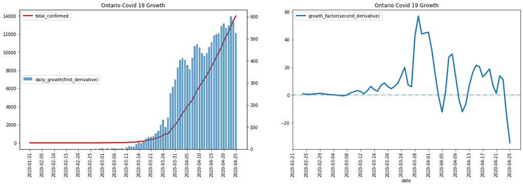

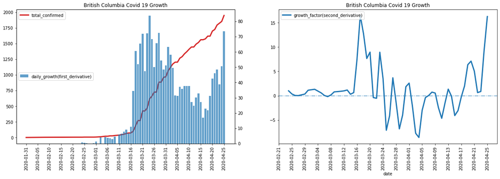

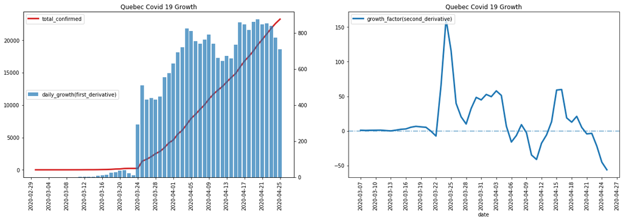

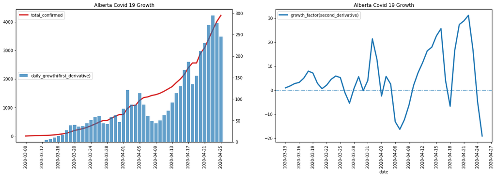

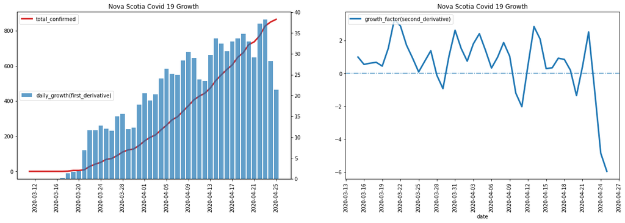

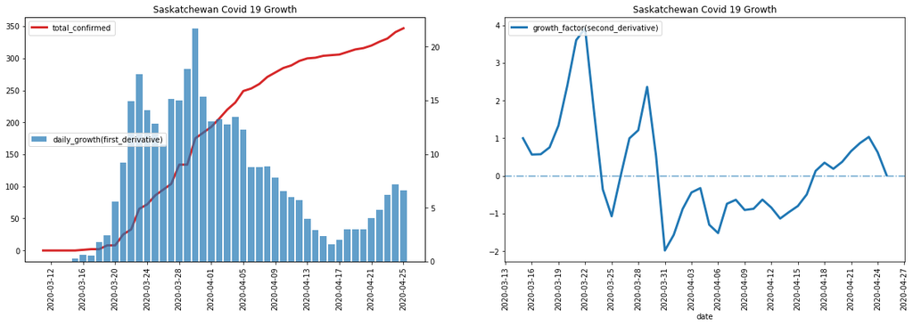

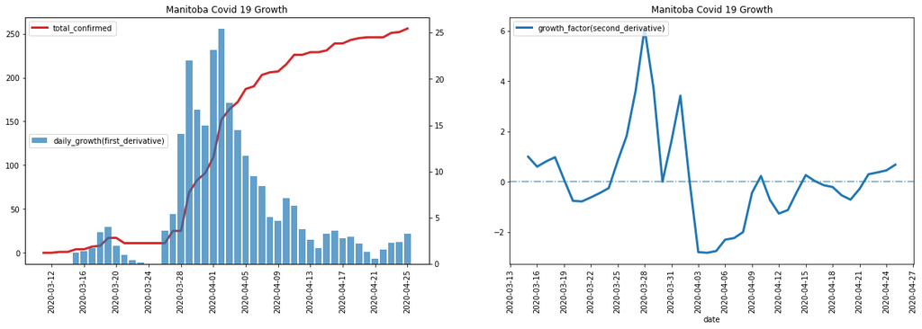

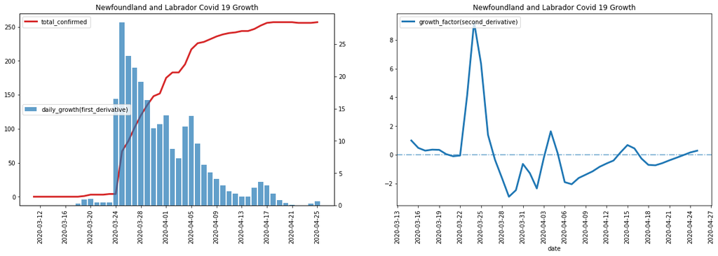

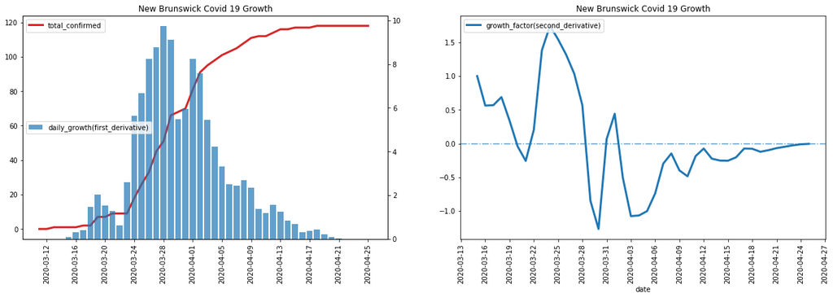

```python
# plot all growth charts
plot_ls = ['Canada','Ontario','British Columbia','Quebec','Alberta','Nova Scotia','Saskatchewan','Manitoba','Newfoundland and Labrador','New Brunswick']
for geo in plot_ls:
    _ = plot_growth(data_confirmed,geo)
```

It seems different provinces are facing very different situation. Confirmed cases in Manitoba, Newfoundland and Labrador has flattened out completely. We can see very similar patterns in growth factor chart for those two cases. Similar to logistic curve, when the confirmed cases start to flatten, the growth factor will drop below zero for a while and gradually return to zero as new cases die out. Among the large provinces BC and Alberta is showing a resurgence of the new cases, which is a reminder that we are living in a real world, which cannot be simplely explained by logistic funciton. If we are not careful things can get worse, even when we think the worst is behind. Situation in Ontariao and Quebec seems to be looking better. According to the pattern we see in anitoba, Newfoundland and Labrador, the growth factor still need to stay below 0 for some days before the comfirmed cases line flattern out completely.

## Trend and Break Point

Another interesting way to look at it is to log transform the curve to straight line and analyze the break point, which can help us answer questions such as at which point there’s a change in the trend, whether our policy worked or not, If so what’s the time lag for it to show effect etc. First of all let’s simulate what will happen to log transform a logistic curve. It should be easy to prove mathematically. But I feel looking at chart is more intuitive.

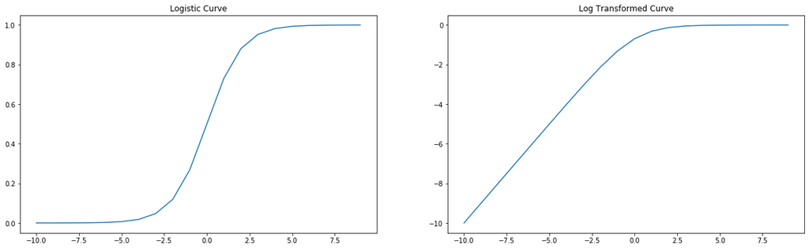

```python
def plot():
    # create logistic data
    x= np.arange(-10,10)
    y = 1/(1+np.e**(x*-1))

    fig,axs = plt.subplots(1,2,figsize=(21,6))
    axs[0].plot(x,y)
    axs[0].set_title('Logistic Curve')
    axs[1].plot(x,np.log(y))
    axs[1].set_title('Log Transformed Curve')
    plt.show()

plot()
```

As the log transform curve pass the inflection point of logistic curve, it will start to curve as well and eventually flattens as the logistic curve get close to the cap. So it gives us more insight of how to interprete the breaking point. Now let's see what it looks like in the really data

```python
def plot_breakpoint(geo,ax):
    df = data_confirmed[data_confirmed.prname==geo][['date','numconf']].set_index('date').dropna()
    df = df.reset_index()
    df.columns = ['ds','y']
    df.y=np.log(df.y).replace([np.inf, -np.inf], 0)
    df.ds = df.ds.apply(lambda x: datetime.strptime(x,'%d-%m-%Y').strftime('%Y-%m-%d'))
    #plot chart
    model = Prophet(growth="linear", daily_seasonality=False, n_changepoints=3,changepoint_prior_scale=0.5,yearly_seasonality=False)
    model.fit(df)
    future = model.make_future_dataframe(periods=0)
    forecast = model.predict(df.ds.to_frame())
    # Create figure
    model.plot(forecast,ax=ax)
    add_changepoints_to_plot(ax, model, forecast)
    ax.set_title(f"{geo} confirmed log over time and change points")
    ax.set_ylabel(f"log (the number of cases)")
    ax.set_xlabel("")
```

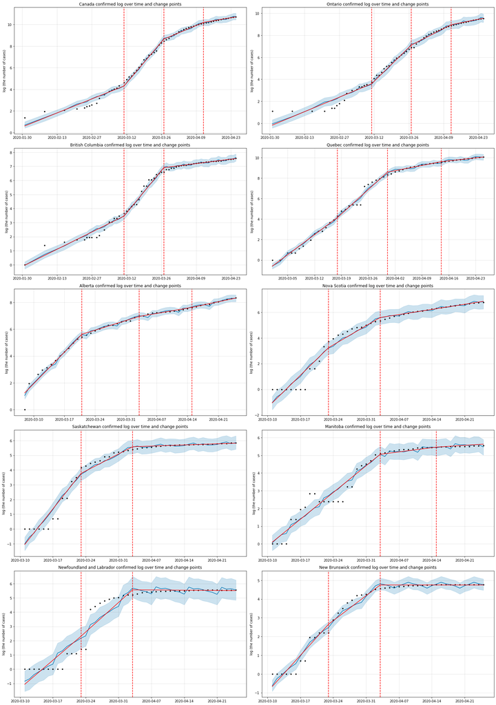

```python
#plot break point chart for all provinces
row_n = int(len(plot_ls)/2)
fig,axs = plt.subplots(row_n,2,figsize=(21,6*row_n))
for geo,ax in zip(plot_ls,axs.flatten()):
    plot_breakpoint(geo,ax)
plt.show()
```

Overall it seems to me the break point in mid March is when it really took off and start to bend down a bit since early to mid april. One thing for sure is that the slope is definitely reducing down. Getting stuck at home for so long is at least paying off.

## SEIR Modeling

In the above analysis we were only looking at the infected portion of the population. But in order to model the dynamics of how the disease spread and how the situation will pan out, we need to take into consideration of the whole population. The model we'll use here is called SEIR model. There’re a lot of variations on this model that takes into consideration of more variables. I’ll leave the links for some of the awesome material I saw in the end. But to not make this post too long we’ll only use this version here.

A lot of the material below is from kaggler funkyboy's post [here](https://www.kaggle.com/super13579/covid-19-global-forecast-seir-visualize). Please check his post for more details. My understanding is that SEIR is a simple model that breaks down a population into one of the following groups:

1. **Susceptible (S).** Refer to the group that has not exposed to the disease due to quarantine or other measures, so will not be infected until exposed.
2. **Esposed (E).** Refer to the group that hasn't contracted the disease, but has been exposed to the disease environment so can be infected.
3. **Infected (I).** Refer to the group that has contracted the disease and can further spread it to others in contact.
4. **Recovered/Deceased (R).** Orginally they Refer to the group that is recovered from the disease. Here we add the deceased group in this variable as well. This group of people can not be infected by the disease again.

We can use this framework to describe how the number of people in each group can change over time.

The differential functions below is a way to formulate the mechanism described above. "R_t" represents, [reproduciton number](https://en.wikipedia.org/wiki/Basic_reproduction_number) at time t, "T_inf" represents Average duration of the infection, T_inc represents average incubation period.

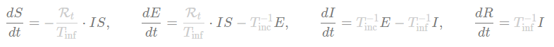

Let's use this model to fit on the Canada data to see what it looks like

```python
data_seir = pd.read_csv('./covid19_web.csv',index_col=0)
```

```python
class Learner(object):
    def __init__(self, predict_range):
        self.predict_range = predict_range
        # load modeling dataset
        self.data = data_seir
        #total population
        self.pop = 37680189
        self.s_0 = (self.pop- self.data.active[0])/self.pop
        self.e_0 =  self.data.active[0]*50/self.pop
        self.i_0 = self.data.active[0]/self.pop
        self.r_0 = 0
        self.T_inf = 2.9
        self.T_inc = 5.2

    def SEIR(self,t, y, R_t, T_inf, T_inc):

        if callable(R_t):
            reproduction = R_t(t)
        else:
            reproduction = R_t

        S, E, I, R = y

        dS_dt = -(reproduction / T_inf) * I * S
        dE_dt = (reproduction / T_inf) * I * S - (T_inc**-1) * E
        dI_dt = (T_inc**-1) * E - (T_inf**-1) * I
        dR_dt = (T_inf**-1) * I

        return [dS_dt, dE_dt, dI_dt, dR_dt]

    def loss_r(self, params, decay, return_solution=False):
        if decay == True:
            R_t, k, L = params
            def time_varying_reproduction(t):
                return R_t / (1 + (t/L)**k)
        else:
            R_t = params[0]
            # R0 become half after intervention days
            def time_varying_reproduction(t):
                if t > 80: # we set intervention days = 80
                    return R_t*0.5
                else:
                    return R_t

        size = len(self.data)
        # Solve the SEIR differential equation.
        sol = solve_ivp(self.SEIR, [0, size], [self.s_0, self.e_0, self.i_0, self.r_0], \
                        args=(time_varying_reproduction, self.T_inf, self.T_inc), t_eval=np.arange(0, size, 1))

        sus, exp, inf, rec = sol.y

        infected_pred = np.clip(inf*self.pop,0,np.inf)
        recovered_pred = np.clip(rec*self.pop,0,np.inf)

        infected_true = self.data.active
        recovered_true = self.data.recover
        optim_days = min(20,size)
        weights = 1 / np.arange(1, optim_days+1)[::-1]  # Recent data is more heavily weighted

        msle_infected = mean_squared_error(infected_true[-optim_days:], infected_pred[-optim_days:], weights)
        msle_recovered = mean_squared_error(recovered_true[-optim_days:], recovered_pred[-optim_days:], weights)
        msle_final = np.mean(msle_infected,msle_recovered)

        if return_solution:
            return msle_final, sol
        else:
            return msle_final

    def train(self,initial_guess=[2.2, 2, 50], bounds=((1, 20), (1, 6), (1, 500)), decay_mode = None):

        ####### Auto find the best decay function #######
        if decay_mode is None:
            opt_const = minimize(self.loss_r, np.array([2.2,]), bounds=((1, 20),),args=(False, False),method='L-BFGS-B')
            opt_decay = minimize(self.loss_r, initial_guess, bounds=bounds,args=(True, False),method='L-BFGS-B')
            if opt_const.fun < opt_decay.fun :
                return opt_const
            else:
                return opt_decay
        else:
            if decay_mode ==True:
                opt_decay = minimize(self.loss_r, initial_guess, bounds=bounds,args=(True, False),method='L-BFGS-B')
                return opt_decay
            else:
                opt_const = minimize(self.loss_r, np.array([2.2,]), bounds=((1, 20),),args=(False, False),method='L-BFGS-B')
                return opt_const

    def extend_index(self, index, new_size):
        values = list(map(lambda x:datetime.strptime(x, '%b %d, %Y'),index.values))
        current = values[-1]
        while len(values) < new_size:
            current = current + timedelta(days=1)
            values = np.append(values, current)
        return values

    def predict(self, R_t, T_inf, T_inc):
        actual = self.data.active
        new_index = self.extend_index(actual.index, self.predict_range)
        size = len(new_index)
        extended_actual = np.concatenate((actual.values, [None] * (size - len(actual.values))))
        return new_index, extended_actual, solve_ivp(self.SEIR, [0, size], [self.s_0, self.e_0, self.i_0, self.r_0], args=(R_t, T_inf, T_inc), t_eval=np.arange(0, size, 1))

    def predict_plot(self,params, title='SEIR model', tick_skip = 4):
        if len(params) != 1:
            R_t, k, L = params
            def time_varying_reproduction(t):
                return R_t / (1 + (t/L)**k)
        else:
            R_t = params[0]
            # R0 become half after intervention days
            def time_varying_reproduction(t):
                if t > 80: # we set intervention days = 80
                    return R_t*0.5
                else:
                    return R_t

        new_index, extended_actual, prediction = self.predict(time_varying_reproduction, self.T_inf, self.T_inc)

        sus, exp, inf, rec = prediction.y
        preds = np.clip(inf * self.pop ,0,np.inf)

        fig = go.Figure(data=[go.Scatter(x=new_index, y=preds, name='Predict Infected Cases'),
                              go.Scatter(x=new_index, y=extended_actual, name='Actual Infected Cases')],
                        layout=go.Layout(
                                title=go.layout.Title(text="Infected Cases Prediction"),
                                title_x=0.5,
                                width=1100,
                                height=700,
                                )
                                )

        fig.show()
```

```python
# 200 days prediction
learn = Learner(200)
# train model
params = learn.train()
```

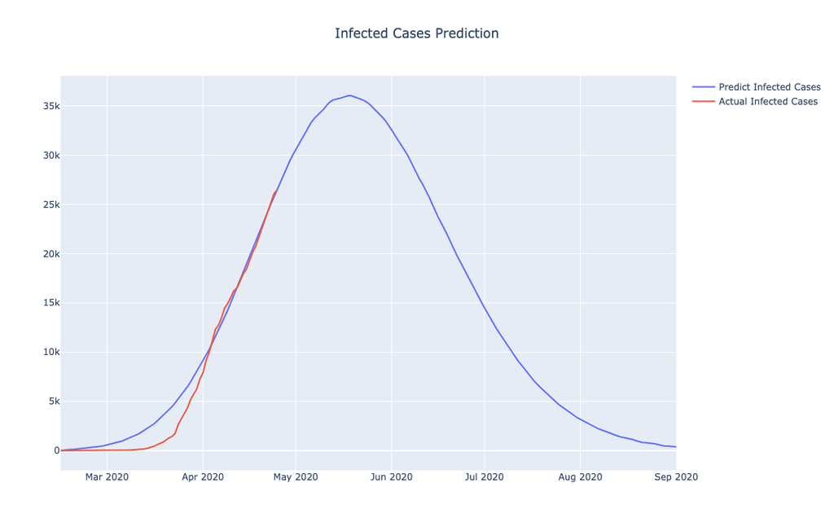

According to the model, it seems the infected cases will peak in mid May at around 36k and return to zero in September. It is an inference based on the reproduciton rate we are looking at in recent 20 days. I'm not a professional in epidemiology so has no insight into how this variable will change in the future. Still this forecast can serve as a simple reference as to what we might expect if things stay in course. Below is some links to other cool posts on this topic you'd like to check out if you want to know more.

- [SEIR-HCD Model](https://www.kaggle.com/anjum48/seir-hcd-model)
- [Covid 19 Senario Simulator](https://covid19-scenarios.org/)
- [SEIR Web App](http://gabgoh.github.io/COVID/index.html)